# Projekt RPiSM cz 3 - rozkład GED

Aleksandra Talaga, Karolina Węgrzyn, Urszula Zastawna

2024-01-21

# Wstęp

Celem projektu jest zbadanie estymatorów Metody Największej Wiarygodności rozkładu GED (Generalized Error Distribution) lub inaczej GND (Generalized Normal Distribution)

## Biblioteki

```r
library(univariateML)
library(fGarch)
library(dplyr)
library(moments)
library(ggplot2)
library(gapminder)
library(reshape2)
library(tidyr)
```

## Teoria dotycząca rozkładu

Rozkład GED, który będziemy badać, posiada trzy parametry:  
**μ - parametr lokalizacji**, w funkcji ged oznaczany jako **mean**  
**α - parametr skali**, w funkcji ged oznaczany jako **sd**  
**β - parametr kształtu**, w funkcji ged oznaczany jako **nu**

## Warianty symulacji

Symulacja będzie przeprowadzona dla różnej liczby danych losowanych z rozkładu GED. Wybraliśmy, że będą to liczności: 10, 50, 100, 200, 500, 1000. Dodatkowo przeprowadzimy ją dla trzech różnych wariantów rozkładu - z różnymi parametrami. Ze względu na ciekawe kształty wykresów, wybrałyśmy:  
I Wariant: mean = 10, sd = 2, nu = 0.5  
II Wariant: mean = 10, sd = 5, nu = 2  
III Wariant: mean = 7, sd = 2, nu = 7

Żeby lepiej zobrazować, jak wyglądają powyższe rozkłady, przedstawimy wykresy ich gęstości, bazując na próbce 1000 danych wylosowanych z rozkładu GED z odpowiednimi parametrami.

```r
dane1 <- rged(1000, mean = 10, sd = 2, nu = 0.5)
dane2 <- rged(1000, mean = 10, sd = 5, nu = 2)
dane3 <- rged(1000, mean = 7, sd = 2, nu = 7)
```

### Wykres krzywych gęstości

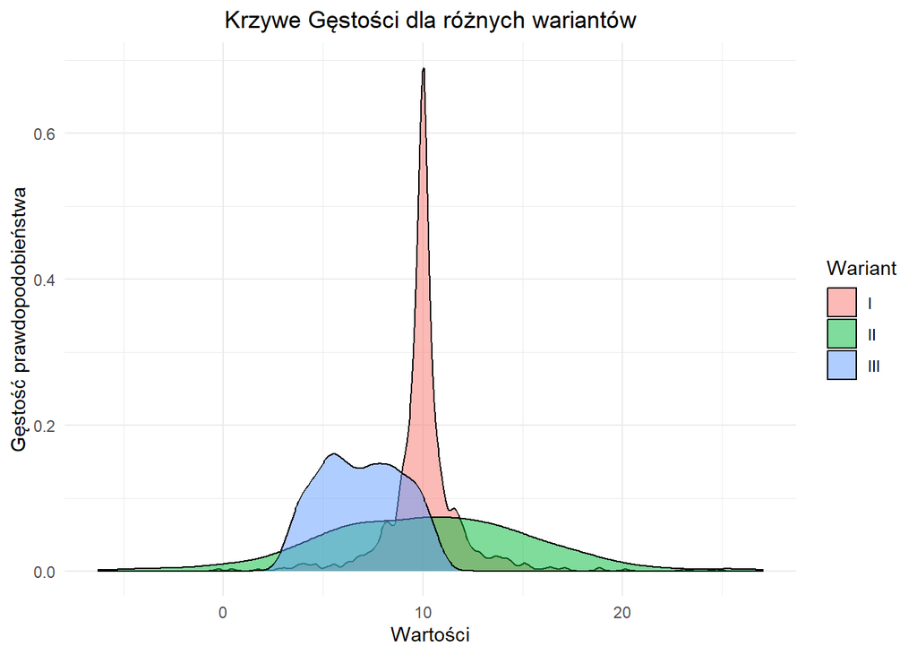

```r
ramka_do_wykresu <- data.frame(
  Dane = c(dane1, dane2, dane3),
  Wariant = rep(c("I", "II", "III"), each = 1000)
)

ggplot(ramka_do_wykresu, aes(x = Dane, fill = Wariant)) +
  geom_density(alpha = 0.5) +
  labs(title = "Krzywe Gęstości dla różnych wariantów",
       x = "Wartości", y = "Gęstość prawdopodobieństwa",
       fill = "Wariant") +
  theme_minimal() +
  theme(plot.title = element_text(hjust = 0.5))
```

Jak widać, rozkłady bardzo różnią się od siebie, szczególnie kształtem i koncentracją. W trakcie przeprowadzania symulacji, będziemy chciały zbadać, czy ma to wpływ na estymowane parametry.

# Funkcje

Do estymowania parametrów rozkładu i odpowiedneiego ich zapisywania, posłuży nam jedna główna funkcja nazwana `funkcja_estymacji()` Korzystamy w niej z gotowej funkcji `mlged()` wbudowanej w pakiet `univariateML`, która służy do estymowania parametrów, używając metody największej wiarygodności. Dla każdej liczby l_values będziemy losować odpowiednią liczbę danych z rozkładu GED, a następnie estymować 300 razy metodą największej wiarygodności. Następnie zajmiemy się badaniem otrzymanych estymatorów.

```r
funkcja_estymacji <- function(l_values, mean_val, sd_val, nu_val) {

  generowanie_danych <- function(l, mean_val, sd_val, nu_val) {
    dane <- rged(l, mean = mean_val, sd = sd_val, nu = nu_val)
    return(dane)
  }

  estymacja <- function(dane) {
    result <- mlged(dane, na.rm = FALSE)
    return(result)
  }

  result_list <- list()

  for (l in l_values) {
    data <- data.frame(matrix(ncol = 3, nrow = 300))
    colnames(data) <- c("Mean", "Sd", "Nu")

    for (i in 1:300) {
      dane <- generowanie_danych(l, mean_val, sd_val, nu_val)
      z <- estymacja(dane)
      data[i, 1] = round(z[1], 4)
      data[i, 2] = round(z[2], 4)
      data[i, 3] = round(z[3], 4)
    }

    result_list[[as.character(l)]] <- data
  }

  return(result_list)
}
```

Bedziemy używać też innych funkcji, które posłużą później do zestawiania ze sobą wyników:

```r
funkcja_zebranie_wynikow <- function(result_data_list, l_values, parametr)
{
  estimated_stat <- matrix(ncol = length(l_values), nrow = 300)
  colnames(estimated_stat) <- l_values

  for (i in seq_along(l_values)) {
    l_val <- l_values[i]
    data <- result_data_list[[as.character(l_val)]]

    if (parametr == "Mean") {
      stat_data <- data[["Mean"]]
    } else if (parametr == "Sd") {
      stat_data <- data[["Sd"]]
    } else if (parametr == "Nu") {
      stat_data <- data[["Nu"]]
    }

    estimated_stat[, i] <- stat_data
  }

  estimated_stat <- data.frame(estimated_stat)
  return(estimated_stat)
}
```

```r
funkcja_statystyki <- function(dane, l_values) {
  statystyki_mean <- data.frame(matrix(nrow = 4, ncol = length(l_values)))

  for (i in seq_along(l_values)) {
    l_val <- l_values[i]
    normal_test <- shapiro.test(dane[, i])
    mean_add <- c(round(mean(dane[, i]), 4), round(skewness(dane[, i]), 4), round(kurtosis(dane[, i]), 4), round(normal_test$p.value, 4))
    statystyki_mean[, i] <- mean_add
  }

  rownames(statystyki_mean) <- c("Średnia", "Skośność", "Kurtoza", "P-value")
  colnames(statystyki_mean) <- c("X10", "X50", "X100", "X200", "X500", "X1000")

  return(statystyki_mean)
}
```

# Przeprowadzenie symulacji

Ustawiamy odpowiednie wartości oraz seed dla powtarzalności symulacji:

```r
set.seed(10)
l_values <- c(10, 50, 100, 200, 500, 1000)
```

## **Wariant I**

Ustawienie odpowiednich wartości parametrów

```r
mean_val = 10
sd_val = 2
nu_val = 0.5
```

### Wykres

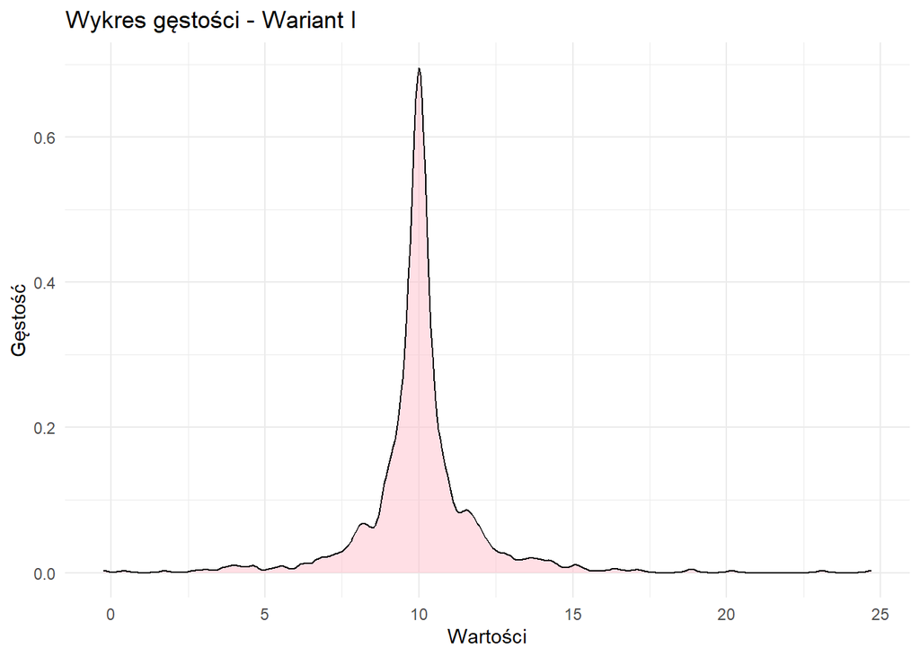

```r
df <- data.frame(x = dane1)

ggplot(df, aes(x)) +
  geom_density(fill = "pink", color = "black", alpha = 0.5) +
  labs(title = "Wykres gęstości - Wariant I",
       x = "Wartości",
       y = "Gęstość") +
  theme_minimal()
```

### Parametr lokalizacji μ

|  | X10 | X50 | X100 | X200 | X500 | X1000 |
| --- | --- | --- | --- | --- | --- | --- |
| Średnia | 9.9988 | 9.9990 | 9.9979 | 10.0002 | 9.9989 | 9.9997 |
| Skośność | 0.0450 | 0.0117 | -0.0578 | 0.1754 | -0.3428 | -0.0801 |
| Kurtoza | 9.5994 | 4.8877 | 4.8901 | 4.5611 | 4.2818 | 3.9977 |
| P-value | 0.0000 | 0.0000 | 0.0000 | 0.0000 | 0.0015 | 0.0051 |

W tabeli przedstawione są podstawowe statystyki opisowe estymatorów parametru lokalizacji μ oraz wynik p-value testu Shapiro-Wilka, który miał sprawdzać, czy rozkład estymatorów jest rozkładem normalnym.  
Widać, że bez względu na liczbę danych, **średnia** za każdym razem wynosi bardzo blisko wartości 10. Oznacza to, że estymatory μ były bardzo blisko rzecziwistej wartości tego parametru. Różnice występują dopiero na trzecim miejscu po przecinku. Nie można więc na razie stwierdzić, że oszacowanie μ jest coraz bardziej dokładne wraz ze wzrostem liczby danych. Jeśli chodzi o **skośność**, tutaj jest ona bliska zeru w każdym z przypadków. Tak naprawdę jedyny przypadek, kiedy ma bardziej znaczący wynik, to przy X500, gdzie wartość około -0.34 sugeruje skośność lewostronną. **Kurtoza** maleje wraz ze wzrostem liczby danych. Oznacza to, że dane są coraz mniej skoncentrowane wokół średniej. Wyniki testu **Shapiro-Wilka** są za każdym razem 0 lub bardzo bliskie zero. Oznacza to, że odrzucamy hipotezę o normalności rozkładu (zawsze w tym badaniu przyjmujemy poziom istotności 0.05), a więc rozkład estymatorów μ nie jest rozkładem normalnym, bez względu na liczbę losowanych danych.

### Parametr skali α

|  | X10 | X50 | X100 | X200 | X500 | X1000 |
| --- | --- | --- | --- | --- | --- | --- |
| Średnia | 690516.5828 | 1.8834 | 1.9224 | 1.9616 | 1.9331 | 1.9629 |
| Skośność | 13.1196 | 0.7782 | 1.0335 | 0.7395 | 0.3104 | 0.1951 |
| Kurtoza | 179.8312 | 3.6084 | 4.6827 | 3.9992 | 3.0572 | 3.0266 |
| P-value | 0.0000 | 0.0000 | 0.0000 | 0.0000 | 0.1218 | 0.3150 |

W przypadku parametru skali od razu rzuca się w oczy ogromna średnia estymatorów dla X10. Podejrzewamy, że z powodu tak małej liczby losowanych danych, późniejsze estymowanie metodą największej wiarygodności mogło skutkować bardzo niestandardowymi wynikami. Pominiemy więc na razie przypadek 10 danych w analizie.  
Wraz ze wzrostem liczby danych **średnia** coraz bardziej zbliża się do 2 czyli do rzeczywistej wartości parametru α. **Skośność** również ma tendencję malejącą już od 100 danych i czym więcej danych, tym bardziej zbliża się do zera, czyli do sytuacji, kiedy rozkład jest symetryczny. Tak naprawdę tylko dla 1000 liczby danych możemy rozkład faktycznie uznać za symetryczny, w pozostałych przypadkach raczej występuje asymetria prawostronna. **Kurtoza** raczej nie waha się istotnie. Widać jednak również tendencję spadkową już od 100 danych, a dla 500 i 1000 danych jest niemal równa 3m co zonacza kurtozę rozkładu normalnego. **Test normalności** dla przyjętego poziomu istotności dla 500 i 1000 danych potwierdza, że estymatory mają rozkład normalny.

### Parametr kształtu β

|  | X10 | X50 | X100 | X200 | X500 | X1000 |
| --- | --- | --- | --- | --- | --- | --- |
| Średnia | 7.460296e+07 | 0.5446 | 0.5196 | 0.5112 | 0.5150 | 0.5081 |
| Skośność | 7.185800e+00 | 1.0856 | 0.4584 | 0.4649 | 0.3684 | 0.3775 |
| Kurtoza | 7.104100e+01 | 5.0480 | 3.5762 | 3.0969 | 3.5148 | 3.3920 |
| P-value | 0.000000e+00 | 0.0000 | 0.0086 | 0.0018 | 0.0234 | 0.0089 |

Tutaj ponownie nie będę brać pod uwagę kolumny z dziesięcioma danymi. Widać, jak bardzo odbiegają one od reszty. Ponownie można wysnuć wniosek, że liczba 10 losowanych danych z rozkładu to za mało, by sensownie oszacować estymatory.  
Dla reszty danych ponownie widać, że wraz ze wzrostem liczby danych, **średnia** estymatorów zbliża się coraz bardziej do 0.5, a więc można wyciągnąć wnioski, że estymatory są coraz bardziej dokładne. Spada również **skośność**, a więc ich rozkład jest coraz bardziej symetryczny, ale jednak za każdym razem występuje symetria prawostronna. **Kurtoza** zachowuje się dość nieregularnie, ale już od 100 danych nie odbiega znacząco od wartości 3. Dla każdej wartości **p-value** odrzucamy hipotezę główną, że rozkład estymatorów jest normalny.

### Obciążenia estymatorów

Sprawdźmy, jeszcze, jak wyglądają średnie bezwzględne obciążenia estymatorów. Dla każdego estymatora wyznaczyliśmy jego różnicę względem rzeczywistej waartości parametru, a następnie wyciągnęliśmy średnią ich wartości bezwzględnych. Celem jest zobaczenie, czy estymatory są coraz bardziej dokładne wraz ze wzrostem liczby losowanych danych.

| Liczba danych | μ - lokalizacja | α - skala | β - kształt |
| --- | --- | --- | --- |
| 10 | 0.31 | 690515.72 | 74602962.20 |
| 50 | 0.07 | 0.48 | 0.11 |
| 100 | 0.04 | 0.34 | 0.08 |
| 200 | 0.02 | 0.24 | 0.04 |
| 500 | 0.02 | 0.16 | 0.03 |
| 1000 | 0.01 | 0.11 | 0.02 |

Zgodnie z przewidywaniami i wnioskami, które pojawiały się już wcześniej przy analizowaniu części statystyk, widać, że **czym więcej danych, tym mniejsze średnie obciążenie estymatorów**. Oznacza to, że aby mieć jak najbardziej zbliżony do rzeczywistego parametru estymator, trzeba wylosować dużo danych z rozkładu. Widać także to,że największe błędy posiada parametr skali - to właśnie w jego przypadku było widać, że wzrost danych miał największe znaczenie na statystyki. W przypadku pozostałych dwóch parametrów różnice te był mniej znaczące. Najmniej wzrost danych wpływał na parametr lokalizacji i to potwierdzają najmniejsze różnice między obciążeniami jego estymatorów dla wszystkich danych powyżej 50. Widać także to, na co zwracałyśmy uwagę w przypadku ogromnych wartości dla parametru skali i kształtu w przypadku 10 danych. Tutaj potwierdza się, że estymatory te został fatalnie dobrane, ponieważ obciążenia są ogromne.

## **Wariant II**

Ustawienie odpowiednich wartości parametrów

```r
mean_val = 10
sd_val = 5
nu_val = 2
```

### Wykres

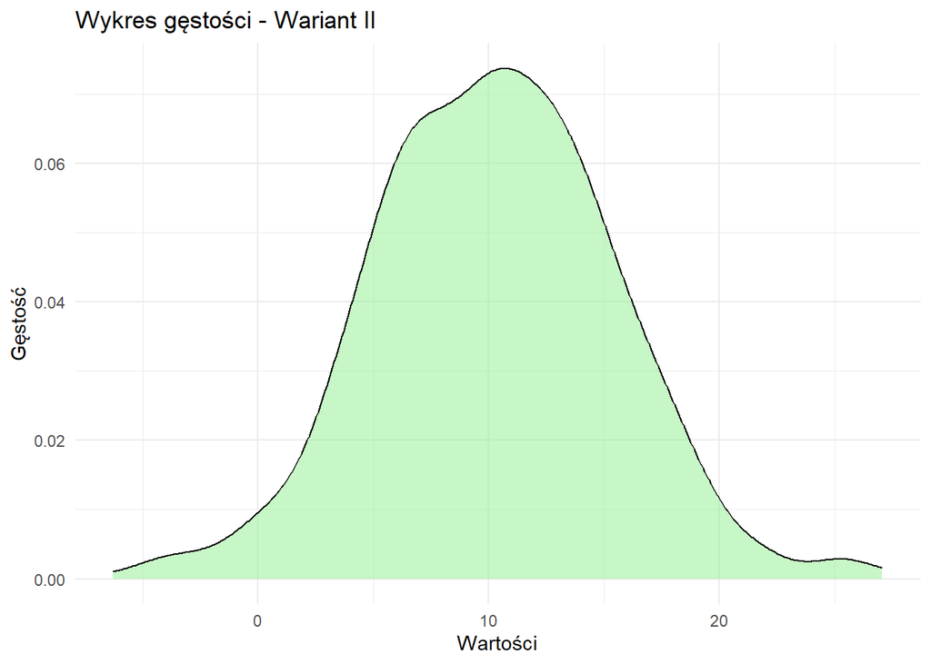

```r
df <- data.frame(x = dane2)

ggplot(df, aes(x)) +
  geom_density(fill = "lightgreen", color = "black", alpha = 0.5) +
  labs(title = "Wykres gęstości - Wariant II",
       x = "Wartości",
       y = "Gęstość") +
  theme_minimal()
```

### Parametr lokalizacji μ

|  | X10 | X50 | X100 | X200 | X500 | X1000 |
| --- | --- | --- | --- | --- | --- | --- |
| Średnia | 10.1092 | 10.0413 | 10.0336 | 9.9855 | 10.0022 | 9.9962 |
| Skośność | 0.0771 | 0.0443 | 0.2271 | 0.0647 | 0.0706 | 0.0980 |
| Kurtoza | 2.9066 | 2.8694 | 2.8721 | 3.2160 | 2.9568 | 3.2526 |
| P-value | 0.8153 | 0.5668 | 0.4881 | 0.5910 | 0.6722 | 0.4628 |

Analogicznie jak w I przypadku **średnia** estymatorów jest dość bliska rzeczywistej wartości parametru μ. **Skośność** za każdym razem niemal równa 0. **Kurtoza** również za każdym razem bliska 3. Nastąpiła natomiast zmiana w **normalności rozkładu** ponieważ w tym przypadku za każdym razem uznajemy, że rozkład estymatorów jest normalny.

### Parametr skali α

|  | X10 | X50 | X100 | X200 | X500 | X1000 |
| --- | --- | --- | --- | --- | --- | --- |
| Średnia | 112.6774 | 4.9472 | 4.9834 | 4.9731 | 4.9817 | 5.0033 |
| Skośność | 16.1140 | 0.0245 | 0.1252 | -0.1209 | -0.0787 | 0.0895 |
| Kurtoza | 269.5460 | 2.9474 | 2.9835 | 2.8241 | 2.7629 | 2.8927 |
| P-value | 0.0000 | 0.9628 | 0.5805 | 0.3220 | 0.6987 | 0.9468 |

Ponownie czym więcej danych tym **średnia** estymatorów zbliża się do 5, czyli rzeczywistej wartości parametru. Różnice między średnimi między 50 a 1000 danych nie są jednak bardzo duże. Dla 10 danych wszystkie statystyki znacząco odbiegają od resztu. **Skośność** zawsze jest bardzo bliska 0m kurtoza zawsze poniżej 3, co oznacza małą koncentrację estymatorów wokół średniej. Jednak wartości tej kurtozy są bliskie kurtozie rozkładu normalnego. Znów nastąpiła zmiana względem wariantu I w **teście Shapiro-wilka**, ponieważ tym razem także w każdym przypadku od 50 danych w górę uznajemy rozkład za normalny.

### Parametr kształtu β

|  | X10 | X50 | X100 | X200 | X500 | X1000 |
| --- | --- | --- | --- | --- | --- | --- |
| Średnia | 8.795334e+07 | 1608667.1583 | 432618.3579 | 2.0623 | 2.0528 | 2.0059 |
| Skośność | 2.794500e+00 | 8.7617 | 17.2338 | 0.2826 | 0.3557 | 0.5147 |
| Kurtoza | 1.254510e+01 | 88.3096 | 298.0033 | 2.6391 | 3.1132 | 4.2784 |
| P-value | 0.000000e+00 | 0.0000 | 0.0000 | 0.0203 | 0.0186 | 0.0008 |

Tutaj nieregularności występują zarówno dla 10 jak i dla 50 i 100 danych, co wcześniej się nie zdarzało. Natomiast od 200 danych w górę potwierdzają się wnioski z wariantu I, znów **średnia** zbliża się do rzeczywistej wartości i osiąga wartość najbliżej niej dla największej ilości danych. **Skośność** jest za każdym razem prawostronna, **kurtoza** zachowuje się dość nieregularnie. Tak samo jak w poprzednim wariancie, za każdym razem odrzuciliśmy hipotezę główną o normalności rozkładu w teście **Shapiro-Wilka**.

### Obciążenia estymatorów

| Liczba danych | μ - lokalizacja | α - skala | β - kształt |
| --- | --- | --- | --- |
| 10 | 1.60 | 109.17 | 87953342.25 |
| 50 | 0.58 | 0.38 | 1608665.44 |
| 100 | 0.40 | 0.26 | 432616.61 |
| 200 | 0.28 | 0.20 | 0.27 |
| 500 | 0.18 | 0.13 | 0.17 |
| 1000 | 0.12 | 0.09 | 0.11 |

Jeśli chodzi o średnie obciążenia, widać analogię do wariantu I, że **czym więcej danych, tym lepsze dopasowanie estymatorów**. Dla 500 i 1000 danych każdy z estymatorów dobrany był bardzo dobrze, bo posiada znikome średnie obciążenie. W poprzednim przypadku największe obciążenia posiadał parametr skali, w tym przypadku dla większych danych posiada on najlepsze spośród trzech dopasowanie. Widać także, że najgorzej przy małej ilości danych radzi sobie parametr kształtu, a najlepiej parametr lokalizacji - analogicznie jak w I przypadku.

## **Wariant III**

Ustawienie odpowiednich wartości parametrów

```r
mean_val = 7
sd_val = 2
nu_val = 7
```

### Wykres

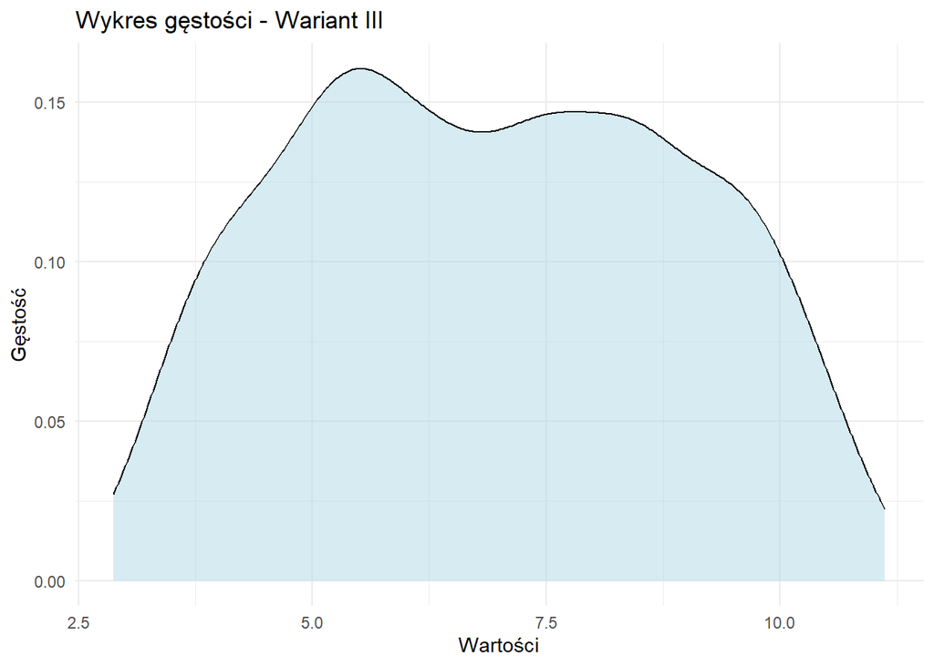

```r
df <- data.frame(x = dane3)

ggplot(df, aes(x)) +
  geom_density(fill = "lightblue", color = "black", alpha = 0.5) +
  labs(title = "Wykres gęstości - Wariant III",
       x = "Wartości",
       y = "Gęstość") +
  theme_minimal()
```

### Parametr lokalizacji μ

|  | X10 | X50 | X100 | X200 | X500 | X1000 |
| --- | --- | --- | --- | --- | --- | --- |
| Średnia | 6.9889 | 6.9996 | 7.0001 | 6.9977 | 6.9951 | 6.9964 |
| Skośność | 0.1772 | -0.1660 | -0.0198 | -0.1613 | -0.2398 | -0.0107 |
| Kurtoza | 3.7089 | 2.9815 | 2.5970 | 2.9149 | 3.0904 | 2.9797 |
| P-value | 0.0680 | 0.6815 | 0.3186 | 0.4436 | 0.1445 | 0.1536 |

Ponownie parametr lokalizacji posiada najmniejsze wahania statystyk między małymi a większymi ilościami danych. **Średnia** zawsze jest bardzo bliska 7. **Kurtoza** niemal zawsze bliska 3, a **skośność** bliska symetrii. **P-value** natomiast każe uznać, że rozkład jest normalny za każdym razem (analogicznie jak w przypadki II, odwrotnie jak w przypadku I)

### Parametr skali α

|  | X10 | X50 | X100 | X200 | X500 | X1000 |
| --- | --- | --- | --- | --- | --- | --- |
| Średnia | 12.3187 | 1.9987 | 2.0055 | 2.0036 | 1.9996 | 1.9998 |
| Skośność | 17.2204 | -0.2361 | 0.0862 | -0.0406 | 0.0460 | 0.0366 |
| Kurtoza | 297.6924 | 2.8471 | 2.9264 | 2.9826 | 2.6732 | 3.0356 |
| P-value | 0.0000 | 0.2706 | 0.9284 | 0.6071 | 0.6123 | 0.6688 |

Wszystko analogicznie jak w II przypadku. Od ilości danych 50 i w górę statystyki coraz bardziej przybliżają się do **symetrii** i **kurtozy** rozkładu normalnego. Rozkład uznajemy za **normalny** dla każdej liczby danych oprócz 10. **Średnia** już dla 50 danych jest bliska rzeczywistej wartości szacowanego parametru i zachowuje się tak dla każdej większej ilości danych.

### Parametr kształtu β

|  | X10 | X50 | X100 | X200 | X500 | X1000 |
| --- | --- | --- | --- | --- | --- | --- |
| Średnia | 1.594556e+08 | 8.195914e+07 | 2.010201e+07 | 610557.5865 | 7.4404 | 7.1355 |
| Skośność | 3.454400e+00 | 6.478700e+00 | 6.604500e+00 | 12.5556 | 1.1801 | 0.5591 |
| Kurtoza | 2.090700e+01 | 6.485990e+01 | 5.249940e+01 | 161.9038 | 5.1431 | 3.1837 |
| P-value | 0.000000e+00 | 0.000000e+00 | 0.000000e+00 | 0.0000 | 0.0000 | 0.0002 |

Widać, że parametr kształtu jest tutaj najgorzej szacowany spośród wszystkich trzech wariantów. Dopiero dla dużej ilości danych (500 i 1000) średnia estymatorów zbliża się do wartości rzeczywistej parametru. Pozostałe statystyki także są zaburzone, dopiero dla 1000 rozkład jest **symetryczny** i ma **kurtozę** jak podobną do rozkładu normalnego. Za każdym razem odrzucamy hipotezę o **normalności rozkładu**.

### Obciążenia estymatorów

| Liczba danych | μ - lokalizacja | α - skala | β - kształt |
| --- | --- | --- | --- |
| 10 | 0.44 | 10.99 | 159455617.75 |
| 50 | 0.17 | 0.10 | 81959136.89 |
| 100 | 0.11 | 0.08 | 20102008.85 |
| 200 | 0.08 | 0.05 | 610551.45 |
| 500 | 0.05 | 0.03 | 1.10 |
| 1000 | 0.03 | 0.02 | 0.66 |

Ponownie potwierdza się to, że **czym więcej danych, tym lepsze dopasowanie estymatorów**, bo obciążenia maleją wraz ze wzrostem liczby danych. W każdym z przypadków to lokalizacja była parametrem, który był najlepiej szacowany dla małej liczby danych i jej wahania między małą a dużą ilością danych były najmniejsze. Najwięcej danych do dobrego oszacowania potrzebuje parametr kształtu. W tym wypadku dopiero przy 500 i 1000 danych można było uznać, że jego oszacowanie jest zbliżone do wartości rzeczywistej.

# Ogólne wnioski

Powyższe rozważania i szczegółowe analizy statystyk i obciążeń estymatorów dla trzech wariantów pozwalają wyciągnąć kilka ogólnych wniosków.  
**1. Czym więcej danych, tym lepsze dopasowanie estymatora** - udodownił to każdy z trzech wariantów.  
**2. Przy małej ilości danych najlepiej radzi sobie estymator lokalizacji μ** - pozostałe dwa parametry nie mogły być estymowane dla małej liczby danych, bo ich wartości znacząco odbiegały od wartości rzeczywistych. Natomiast wahania estymatora μ między największą a najmniejszą liczbą danych nie były znaczące. Wszytkie oszacowania można było uznać za dobre.  
**3. Estymatory kształtu β nie mają rozkładu normalnego** - za każdym razem w każdym wariancie odrzucaliśmy hipotezę główną.  
**4. Przy małej ilości danych najgorzej radzi sobie estymator kształtu β** - w każdym wariancie, a szczególnie w trzecim widać było, jak bardzo różnią się oszacowania przy małej ilości danych względem tych przy dużej ilości danych.  
Reszta aspektów różniła się między sobą w zależności od wariantu. Można więc uznać, że na wartość estymowanego parametru ma wpływ zarówno jego wartość rzeczywista, jak i pozostałe wartości parametrów rozkładu. Kwestia estymatorów jest więc bardzo złożona.